# Vector FFT Float

# Vector FFT Float

The Vector FFT Float block supports the FFT operation for vector single-precision floating-point inputs. This block only supports Versal devices.

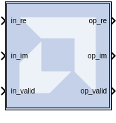

## Description

The real part of the input data should be given to the in_re port, and the imaginary part should be given to the in_im port.

## Parameters

#### FFT length (N)

N is the size of the transformation, and should be powers of 2 in the range of 2^3 to 2^16.

#### SSR (R)

R is the super sample rate, the number of samples processed in parallel every clock. Using a typical example with N=1024 and SSR=4, the core would compute one 1K FFT every 256 clock cycles, processing 4 input samples/clock.

The SSR is limited to 2 and 4.

#### Block RAM_THRESHOLD

Is an implementation parameter with no functional implications. It controls the use of distributed RAM vs BRAM when implementing delay lines. It can be used to trade utilization numbers between these two types of resources. The higher the value, the more distributed RAM will be used instead of BRAM. Typical values to try are 258, 514, and 1026.

## Examples

**Click on the images below to open each model.**

[figure not shown]

[figure not shown]

Copyright (C) 2025 Advanced Micro Devices, Inc. All rights reserved.

SPDX-License-Identifier: MIT